# Ford GoBike Exploration

## Dataset Overview

This dataset includes 519,700 trips with 15 features such as locations, time, and user attributes. The dataset is subsetted by choosing top 8 trips start stations with the most trips due to the same stations with same amount of trips in the end stations. Also, June's data is removed because of lack of insufficient data in that month.

## The top 8 stations with the most trips

All of the start stations with the most trips are in San Francisco and connect to public transportations such as Caltrain, Bart and Ferry.

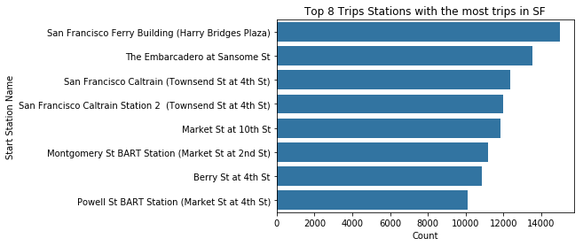

## The time with most trips

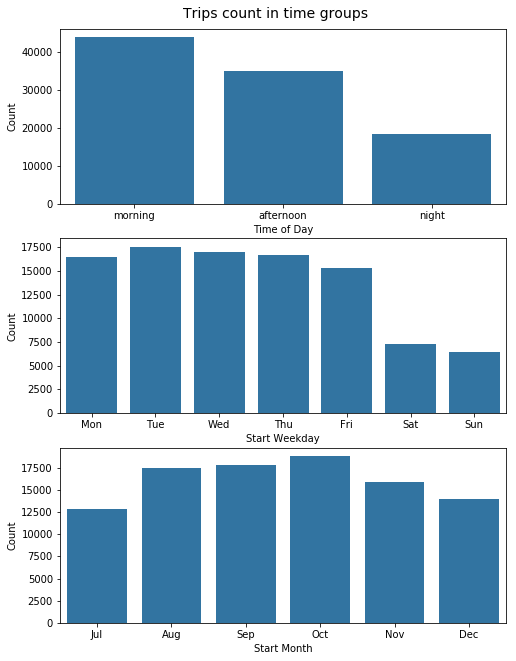

## The top 8 stations with the most trips by weekdays in each user type

After separating user types, for customers, there are 6 out of 8 stations with the most trips in the weekend. Majority of the trips happened at Ferry Building and Embarcadero which happen to be very popular tourist attractions. On the other hand, for subscribers, most of trips happen during the weekdays. Subscribers are more likely commuters and customers tourists

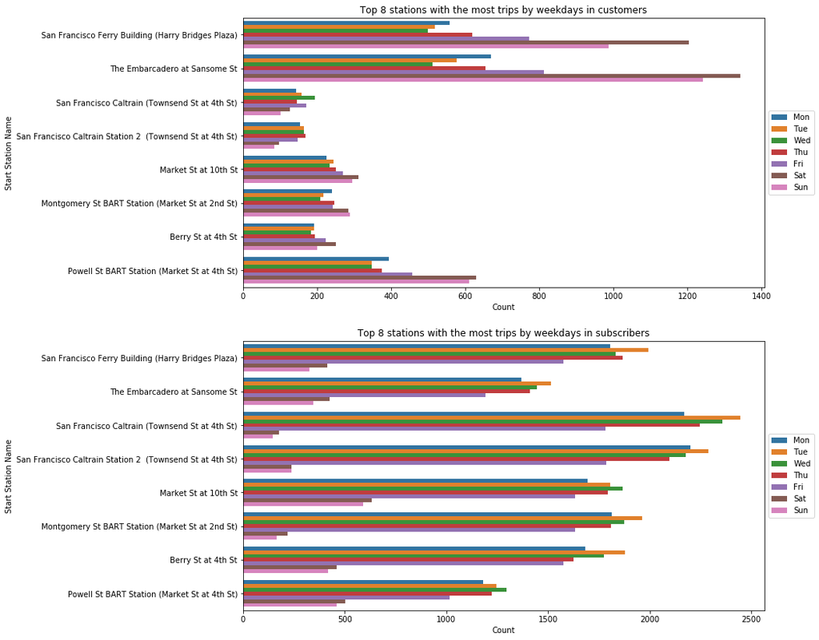

## The top 8 stations with the most trips by months in each user type

The distributions in each month support that customers might include tourists because the most trips happen in August at Ferry Building and Embarcadero. For subscribers, the numbers of trips gradually increase from July to October and decrease in November and December according to the climate changes.

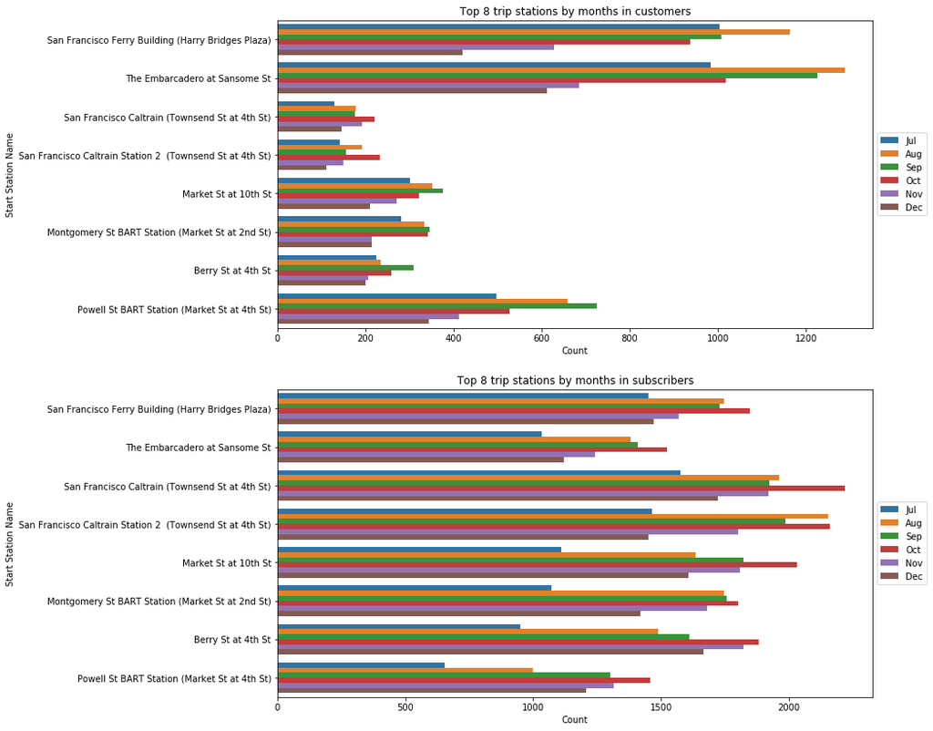

## Summary

All of the most trips happen at the stations in San Francisco. User types play an important role here to impact the number of trips in each time groups. Thus, getting more user types' attributes will help understand the characteristics of trips more and attract higher traffics for this program.